# Lab Report for OpenIntro Statistics Lab 1

2024-02-15

```r
data(arbuthnot)
```

## Data Visualization:

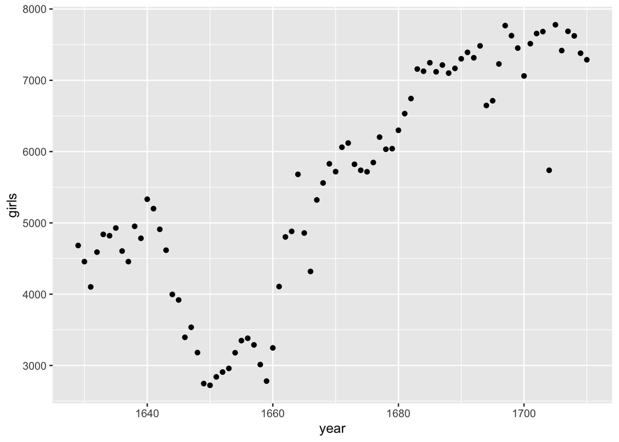

```r
ggplot(data = arbuthnot, aes(x = year, y = girls)) + geom_point()
```

The function **ggplot()** builds the plot and the arguments used are data(data set name), aes(x and y axis). Then you need to add a layer to the blank ggplot() with **+ geom_point()** aka scatterplot

*To make a line graph instead use **+ geom_line()**

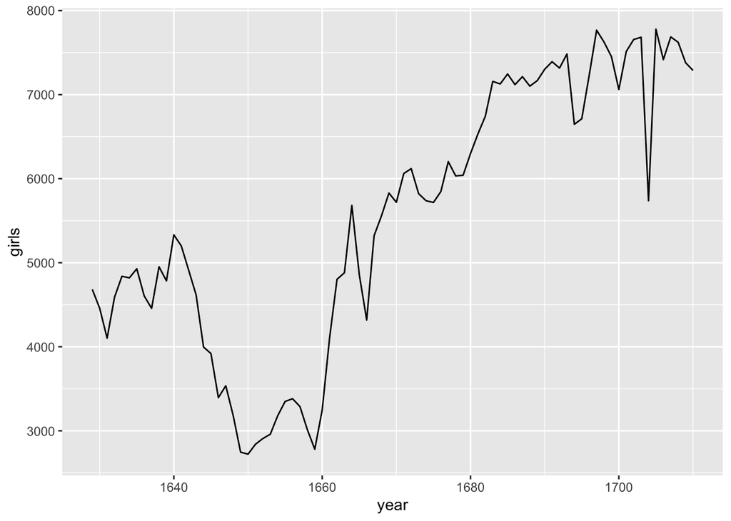

```r
ggplot(data = arbuthnot, aes(x = year, y = girls)) + geom_line()
```

### Exercise 2

The line graph above shows that, overall, the number of girls baptized in London increased from 1629 to 1710.

## Adding a New Variable to the Data Frame

To calculate the total number of baptisms each year, add the vector for boys to the vector for girls.

```r
arbuthnot <- arbuthnot %>%
  mutate(total = boys + girls)
```

The %>% is the piping operator that takes the output of the previous expression and “pipes it” into the first argument of the next expression arbuthnot %>% piping into the next expression

I could have used: mutate(arbuthnot, total = boys + girls)

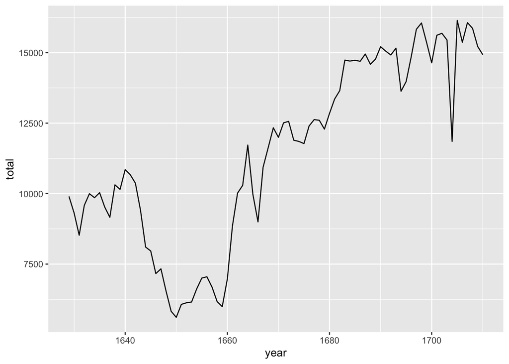

```r
ggplot(data = arbuthnot, aes(x = year, y = total)) + geom_line()
```

To find the boy to girl ratio for the whole column save the ratio calculation for each row into a new variable in the table

### Exercise 3

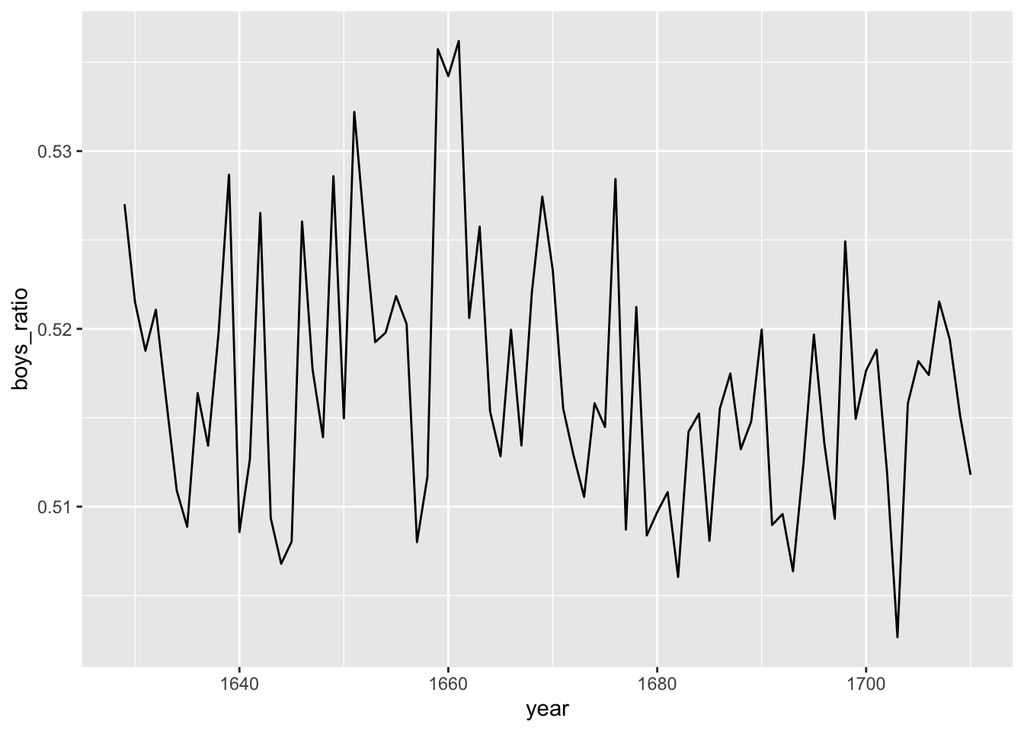

```r
arbuthnot <- arbuthnot %>% mutate(boys_ratio = boys / total)
ggplot(data = arbuthnot, aes(x = year, y= boys_ratio)) + geom_line()
```

```r
arbuthnot <- arbuthnot %>% mutate(more_boys = boys > girls)
```

This new variable contains a true or false value called *logical* data

## More Practice

### Exercise 4

The years on the present data set are from 1940-2002. The dimensions of the data set are x = years, y = number of boy births, number of girl births. The variable names are year, boy, girl.

### Exercise 5

How do these counts compare to Arbuthnot’s? Are they of a similar magnitude?

```r
summary(arbuthnot)
```

```
##       year           boys          girls          total         boys_ratio
##  Min.   :1629   Min.   :2890   Min.   :2722   Min.   : 5612   Min.   :0.5027
##  1st Qu.:1649   1st Qu.:4759   1st Qu.:4457   1st Qu.: 9199   1st Qu.:0.5118
##  Median :1670   Median :6073   Median :5718   Median :11813   Median :0.5157
##  Mean   :1670   Mean   :5907   Mean   :5535   Mean   :11442   Mean   :0.5170
##  3rd Qu.:1690   3rd Qu.:7576   3rd Qu.:7150   3rd Qu.:14723   3rd Qu.:0.5210
##  Max.   :1710   Max.   :8426   Max.   :7779   Max.   :16145   Max.   :0.5362
##  more_boys
##  Mode:logical
##  TRUE:82
##
##
##
##
```

```r
summary(present)
```

```
##       year           boys             girls
##  Min.   :1940   Min.   :1211684   Min.   :1148715
##  1st Qu.:1956   1st Qu.:1799857   1st Qu.:1711404
##  Median :1971   Median :1924868   Median :1831679
##  Mean   :1971   Mean   :1885600   Mean   :1793915
##  3rd Qu.:1986   3rd Qu.:2058524   3rd Qu.:1965538
##  Max.   :2002   Max.   :2186274   Max.   :2082052
```

The number of births recorded in London from 1629-1710 were lower than the recorded births in the US from 1940-2002. The magnitude for present births are much higher.

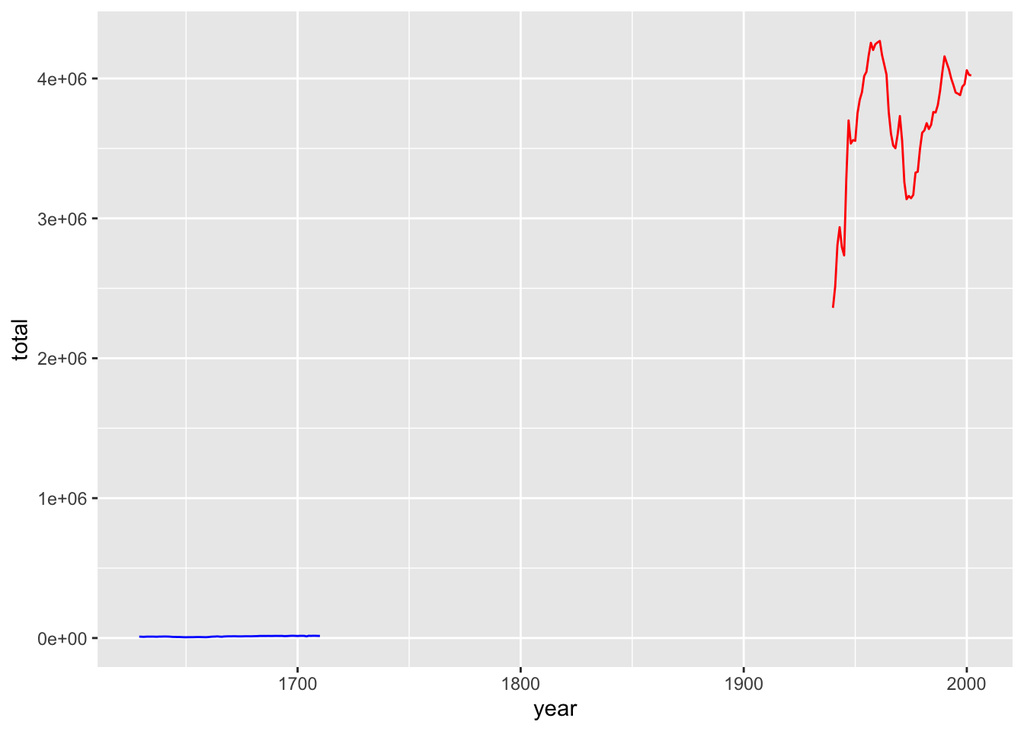

```r
present <- present %>% mutate(total = boys + girls)
ggplot() + geom_line(data = arbuthnot, aes(x = year, y = total), color = "blue") + geom_line(data = present, aes(x = year, y = total), color = "red")
```

### Exercise 6

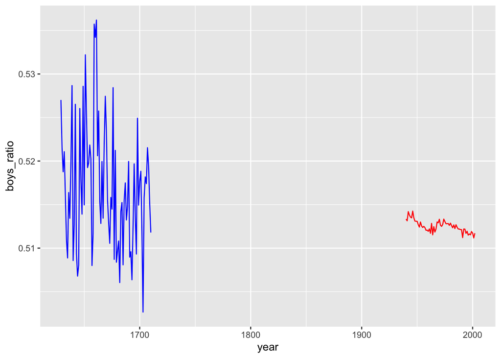

```r
present <- present %>% mutate(boys_ratio = boys / total)
ggplot() + geom_line(data = arbuthnot, aes(x = year, y = boys_ratio), color = "blue") + geom_line(data = present, aes(x = year, y = boys_ratio), color = "red")
```

### Exercise 7

```r
present %>% arrange(desc(total))
```

```
## # A tibble: 63 × 5
##     year    boys   girls   total boys_ratio
##    <dbl>   <dbl>   <dbl>   <dbl>      <dbl>
##  1  1961 2186274 2082052 4268326      0.512
##  2  1960 2179708 2078142 4257850      0.512
##  3  1957 2179960 2074824 4254784      0.512
##  4  1959 2173638 2071158 4244796      0.512
##  5  1958 2152546 2051266 4203812      0.512
##  6  1962 2132466 2034896 4167362      0.512
##  7  1956 2133588 2029502 4163090      0.513
##  8  1990 2129495 2028717 4158212      0.512
##  9  1991 2101518 2009389 4110907      0.511
## 10  1963 2101632 1996388 4098020      0.513
## # ℹ 53 more rows
```

The most total number of births in the US happened in 1961